# TSLA_stockprice

## Introduction

My objective is to predict the day price direction of Tesla, Inc. (TSLA). The stock market is a highly complex and volatile environment. To achieve profitability, it's not necessary to predict the exact price of a stock, but rather its price direction: whether it will be higher or lower than it is today. For Tesla, this means predicting if the next day's closing price will be higher than the opening price. If we anticipate a rise, we might choose to buy some shares; if we foresee a decline, selling might be the better option. Thus, the goal is a binary classification to determine whether the next day's closing price for Tesla will be higher than its opening price.

## Data Exploration

In our initial phase of exploration, I will load the datasets and examine the available data attributes. Additionally, I will plot the variables to identify any trends and investigate the potential for engineering additional features. I will use the pandas library for data loading and analysis, so let's load the library and start exploring.

```python
import pandas as pd
```

```python
# load the training set
df_train = pd.read_csv("TSLA_train.csv")
```

```python
# (#rows, #columns)
df_train.shape
```

```
(2519, 7)
```

```python
df_train.info()
```

```
<class 'pandas.core.frame.DataFrame'>
RangeIndex: 2519 entries, 0 to 2518
Data columns (total 7 columns):
 #   Column     Non-Null Count  Dtype
---  ------     --------------  -----
 0   Date       2519 non-null   object
 1   Open       2519 non-null   float64
 2   High       2519 non-null   float64
 3   Low        2519 non-null   float64
 4   Close      2519 non-null   float64
 5   Adj Close  2519 non-null   float64
 6   Volume     2519 non-null   int64
dtypes: float64(5), int64(1), object(1)
memory usage: 137.9+ KB
```

Pandas' info() method is really useful to get a quick peek at the column names, types, non-null counts, as well as the data set's memory size! I have mostly numerical columns (5 floats, 1 int) and an object column - the date. No null values at all, and just 137 KB in size. The training data set consists of 2519 rows and 7 columns. These are presented above. In the cell below, I use the describe() method to get a quick overview of our data set.

```python
df_train.describe()
```

|  | Open | High | Low | Close | Adj Close | Volume |
| --- | --- | --- | --- | --- | --- | --- |
| count | 2519.000000 | 2519.000000 | 2519.000000 | 2519.000000 | 2519.000000 | 2.519000e+03 |
| mean | 14.030870 | 14.306071 | 13.749579 | 14.037992 | 14.037992 | 9.059986e+07 |
| std | 11.158928 | 11.436247 | 10.887421 | 11.178008 | 11.178008 | 8.448232e+07 |
| min | 1.076000 | 1.108667 | 0.998667 | 1.053333 | 1.053333 | 1.777500e+06 |
| 25% | 2.342666 | 2.376000 | 2.302667 | 2.341666 | 2.341666 | 3.049800e+07 |
| 50% | 14.523333 | 14.765333 | 14.284667 | 14.542000 | 14.542000 | 7.176600e+07 |
| 75% | 18.900333 | 19.239334 | 18.574666 | 18.954333 | 18.954333 | 1.175040e+08 |
| max | 81.431999 | 81.866669 | 79.040001 | 80.577332 | 80.577332 | 9.140820e+08 |

```python
# the above call to describe() works only for numerical columns
# 'Date' is an object and I need to call it separately
df_train["Date"].describe()
```

```
count           2519
unique          2519
top       2010-07-01
freq               1
Name: Date, dtype: object
```

```python
# print the time range
df_train["Date"].min(), df_train["Date"].max()
```

```
('2010-07-01', '2020-07-02')
```

```python
# print the time range
df_train["Date"].min(), df_train["Date"].max()
```

```
('2010-07-01', '2020-07-02')
```

I can plot the stock prices as a function of time. These plots are the first thing you see on any stock market.

```python
from matplotlib import pyplot as plt

plt.rcParams["figure.figsize"] = (12, 9)
```

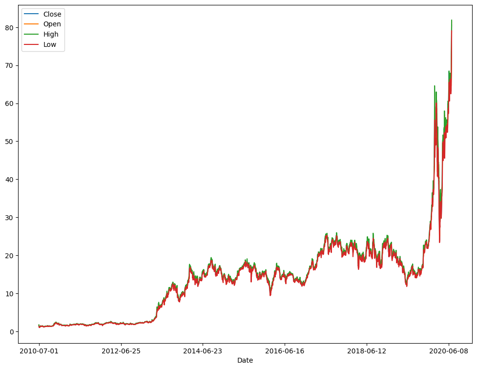

```python
_ = df_train.plot(x="Date", y=["Close", "Open", "High", "Low"])
```

I repeat the same analysis for the validation and testing set, to make sure that they follow a similar distribution and that there are no surprising errors there. I create a function to do that.

```python
def analyse(dataframe):
    """Runs an exploration analysis of the dataframe."""
    print("Shape", dataframe.shape, "\n")
    print("Columns", dataframe.columns, "\n")
    dataframe.info()
    print("\n", dataframe.describe(), "\n")
    print("The data ranges from", dataframe["Date"].min(), "to", dataframe["Date"].max())
    dataframe.plot(x="Date", y=["Close", "Open", "High", "Low"])
```

```
Shape (504, 7)

Columns Index(['Date', 'Open', 'High', 'Low', 'Close', 'Adj Close', 'Volume'], dtype='object')

<class 'pandas.core.frame.DataFrame'>
RangeIndex: 504 entries, 0 to 503
Data columns (total 7 columns):
 #   Column     Non-Null Count  Dtype
---  ------     --------------  -----
 0   Date       504 non-null    object
 1   Open       504 non-null    float64
 2   High       504 non-null    float64
 3   Low        504 non-null    float64
 4   Close      504 non-null    float64
 5   Adj Close  504 non-null    float64
 6   Volume     504 non-null    int64
dtypes: float64(5), int64(1), object(1)
memory usage: 27.7+ KB

              Open        High         Low       Close   Adj Close  \
count  504.000000  504.000000  504.000000  504.000000  504.000000
mean   239.307651  244.916657  233.103357  239.161009  239.161009
std     74.059488   75.642560   72.071929   73.745700   73.745700
min     85.112663   91.852669   84.402664   91.058670   91.058670
25%    200.806668  206.431671  198.260834  201.685833  201.685833
50%    235.671669  239.836670  231.379997  236.125000  236.125000
75%    286.415841  292.894997  280.500832  288.062508  288.062508
max    411.470001  414.496674  405.666656  409.970001  409.970001

             Volume
count  5.040000e+02
mean   1.089754e+08
std    7.304502e+07
min    2.940180e+07
25%    6.678052e+07
50%    8.760945e+07
75%    1.211540e+08
max    6.663786e+08

The data ranges from 2020-07-06 to 2022-07-05
```

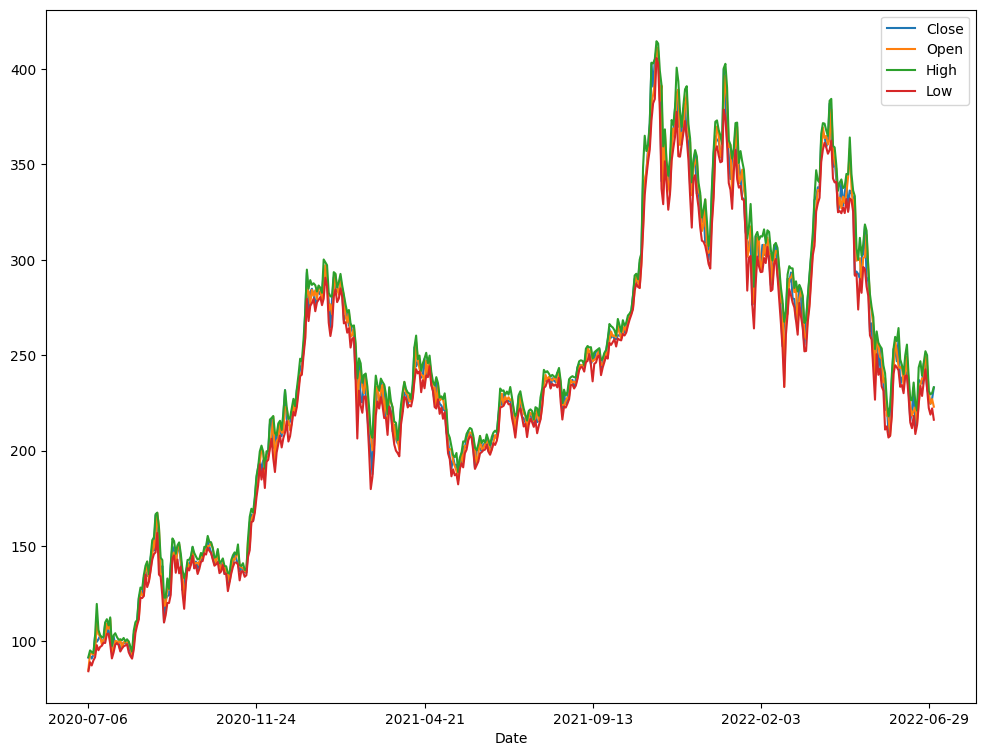

```python
# read validation and test sets and then analyse them
df_val = pd.read_csv("TSLA_val.csv")
analyse(df_val)
```

```
Shape (500, 7)

Columns Index(['Date', 'Open', 'High', 'Low', 'Close', 'Adj Close', 'Volume'], dtype='object')

<class 'pandas.core.frame.DataFrame'>
RangeIndex: 500 entries, 0 to 499
Data columns (total 7 columns):
 #   Column     Non-Null Count  Dtype
---  ------     --------------  -----
 0   Date       500 non-null    object
 1   Open       500 non-null    float64
 2   High       500 non-null    float64
 3   Low        500 non-null    float64
 4   Close      500 non-null    float64
 5   Adj Close  500 non-null    float64
 6   Volume     500 non-null    int64
dtypes: float64(5), int64(1), object(1)
memory usage: 27.5+ KB

              Open        High         Low       Close   Adj Close  \
count  500.000000  500.000000  500.000000  500.000000  500.000000
mean   213.729247  218.128247  209.140686  213.697160  213.697160
std     45.150331   45.682988   44.544052   45.095227   45.095227
min    103.000000  111.750000  101.809998  108.099998  108.099998
25%    178.970005  183.589996  175.530003  179.675006  179.675006
50%    207.099998  211.820000  201.055001  207.310005  207.310005
75%    250.055004  254.845001  244.420002  249.925003  249.925003
max    311.666656  314.666656  305.579987  309.320007  309.320007

             Volume
count  5.000000e+02
mean   1.148549e+08
std    4.065490e+07
min    4.186470e+07
25%    8.618472e+07
50%    1.095094e+08
75%    1.354766e+08
max    3.065906e+08

The data ranges from 2022-07-06 to 2024-07-01
```

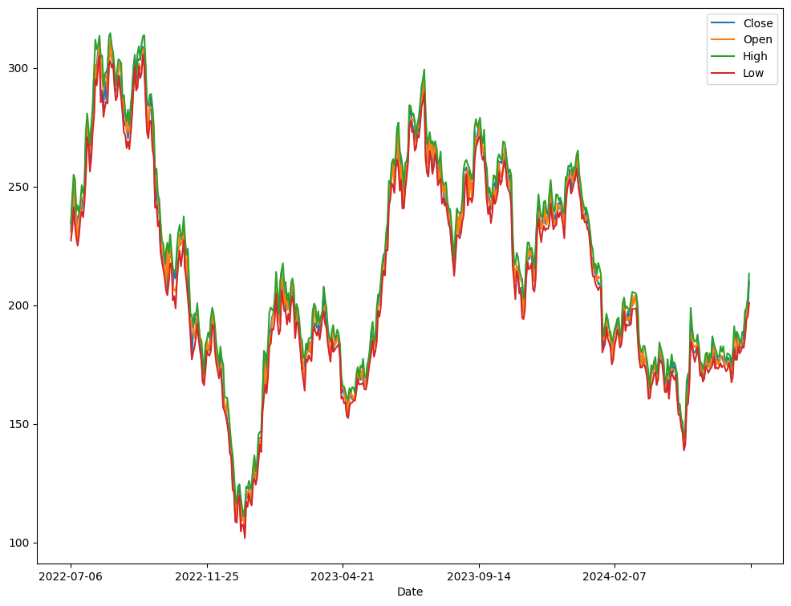

```python
df_test = pd.read_csv("TSLA-test.csv")
analyse(df_test)
```

Once I have explored the data, I moved on to the predictive modeling phase. My objective is to predict whether the next day's closing price will be higher than the opening price. Since this information isn't explicitly available in the data, I need to infer it.

To do this, I first ensure the data is sorted by date using the sort_values method, passing in the Date column as a parameter and sorting it in ascending order.

Next, I will shift the DataFrame by one row (one day) to compare the prices. Pandas provides the shift method for this purpose, allowing me to shift the data from the next day back by specifying a period of minus one. Since this is a logical operation, Pandas will return a True/False result for each comparison. I will convert these to 1/0 for use in my machine learning models by mapping the results to integers. To store this information, I will create a new column called Target.

```python
# make sure that our data is sorted by date
df_train.sort_values(by="Date", inplace=True)
df_val.sort_values(by="Date", inplace=True)
df_test.sort_values(by="Date", inplace=True)
```

```python
# notice that I shift by a period of '-1', this takes the next day's price direction for the current day
# a positive period will take the days from the past
df_train["Target"] = (df_train["Close"] > df_train["Open"]).shift(periods=-1, fill_value=0).astype(int)
```

```python
df_train
```

|  | Date | Open | High | Low | Close | Adj Close | Volume | Target |
| --- | --- | --- | --- | --- | --- | --- | --- | --- |
| 0 | 2010-07-01 | 1.666667 | 1.728000 | 1.351333 | 1.464000 | 1.464000 | 123282000 | 0 |
| 1 | 2010-07-02 | 1.533333 | 1.540000 | 1.247333 | 1.280000 | 1.280000 | 77097000 | 0 |
| 2 | 2010-07-06 | 1.333333 | 1.333333 | 1.055333 | 1.074000 | 1.074000 | 103003500 | 0 |
| 3 | 2010-07-07 | 1.093333 | 1.108667 | 0.998667 | 1.053333 | 1.053333 | 103825500 | 1 |
| 4 | 2010-07-08 | 1.076000 | 1.168000 | 1.038000 | 1.164000 | 1.164000 | 115671000 | 0 |
| ... | ... | ... | ... | ... | ... | ... | ... | ... |
| 2514 | 2020-06-26 | 66.318665 | 66.333336 | 63.658001 | 63.982666 | 63.982666 | 132823500 | 1 |
| 2515 | 2020-06-29 | 64.600670 | 67.333336 | 63.234669 | 67.290001 | 67.290001 | 135396000 | 1 |
| 2516 | 2020-06-30 | 67.099998 | 72.512665 | 66.915337 | 71.987335 | 71.987335 | 253777500 | 1 |
| 2517 | 2020-07-01 | 72.199997 | 75.688667 | 72.033333 | 74.641998 | 74.641998 | 199903500 | 0 |
| 2518 | 2020-07-02 | 81.431999 | 81.866669 | 79.040001 | 80.577332 | 80.577332 | 258751500 | 0 |

2519 rows × 8 columns

```python
df_train["Target"].value_counts()
```

```
0    1270
1    1249
Name: Target, dtype: int64
```

Running the value_counts method on the Target column gives us the distribution. We have 1249 days where the closing price is higher than the opening and 1270 where it is lower.

I am going to repeat the same procedure for the validation as well as the test set.

```python
df_val["Target"] = (df_val["Close"] > df_val["Open"]).shift(periods=-1, fill_value=0).astype(int)
df_val["Target"].value_counts()
```

```
0    255
1    249
Name: Target, dtype: int64
```

We have 249 days where the closing price is higher than the opening and 255 where it is lower.

```python
df_test["Target"] = (df_test["Close"] > df_test["Open"]).shift(periods=-1, fill_value=0).astype(int)
df_test["Target"].value_counts()
```

```
1    251
0    249
Name: Target, dtype: int64
```

We have 251 days where the closing price is higher than the opening and 249 where it is lower.

At this point, I can start building some machine learning models to predict the target variable. But, before I do that, it might be useful to engineer some additional features that may help me better predict the price direction. In the next section, I will explore some possibilities for doing feature engineering.

Stock prices are inherently time-dependent, with the next day's price influenced by prices and various other factors from previous days. To account for the values from the last n days and capture trends or the magnitude of price changes, I need to consider the historical data.

One simple approach is to calculate a moving average. In Pandas, the rolling method allows for sliding window calculations, making it easy to compute moving averages. By using this method, I can calculate the 3-day and 7-day moving averages and add them as features to the dataset.

Here's how it works: first, I ensure the data is sorted by date. If the data isn't sorted, the results from the rolling method would be invalid. With sorted data, I then use the rolling method to calculate the moving averages over the desired window lengths and add these values as new columns in the dataset. This process helps capture the underlying trends in the stock prices over time.

```python
df_train["Moving_Average_3"] = (df_train["Close"] - df_train["Open"]).rolling(window=3, min_periods=1).mean()
df_val["Moving_Average_3"] = (df_val["Close"] - df_val["Open"]).rolling(window=3, min_periods=1).mean()
df_test["Moving_Average_3"] = (df_test["Close"] - df_test["Open"]).rolling(window=3, min_periods=1).mean()
```

```python
df_train["Moving_Average_7"] = (df_train["Close"] - df_train["Open"]).rolling(window=7, min_periods=1).mean()
df_val["Moving_Average_7"] = (df_val["Close"] - df_val["Open"]).rolling(window=7, min_periods=1).mean()
df_test["Moving_Average_7"] = (df_test["Close"] - df_test["Open"]).rolling(window=7, min_periods=1).mean()
```

Feature engineering can be simpler, I can just take the current day's price direction or the price range. Anything that comes to mind, that can be considered to be useful, should be tested and tried.

```python
# current price direction
df_train["Today_Direction"] = df_train["Close"] - df_train["Open"]
df_val["Today_Direction"] = df_val["Close"] - df_val["Open"]
df_test["Today_Direction"] = df_test["Close"] - df_test["Open"]
```

```python
# price range
df_train["Price_Range"] = df_train["High"] - df_train["Low"]
df_val["Price_Range"] = df_val["High"] - df_val["Low"]
df_test["Price_Range"] = df_test["High"] - df_test["Low"]
```

```python
df_train.sample(10, random_state=42)
```

|  | Date | Open | High | Low | Close | Adj Close | Volume | Target | Moving_Average_3 | Moving_Average_7 | Today_Direction | Price_Range |
| --- | --- | --- | --- | --- | --- | --- | --- | --- | --- | --- | --- | --- |
| 2197 | 2019-03-26 | 17.629333 | 18.017332 | 17.628668 | 17.851334 | 17.851334 | 110263500 | 1 | -0.089111 | -0.049714 | 0.222001 | 0.388664 |
| 410 | 2012-02-15 | 2.206667 | 2.294000 | 2.151333 | 2.240000 | 2.240000 | 41427000 | 1 | 0.041555 | 0.013524 | 0.033333 | 0.142667 |
| 1389 | 2016-01-07 | 14.279333 | 14.562667 | 14.244667 | 14.376667 | 14.376667 | 53314500 | 0 | -0.054000 | 0.003619 | 0.097334 | 0.318000 |
| 888 | 2014-01-10 | 9.897333 | 9.926667 | 9.483333 | 9.714667 | 9.714667 | 111691500 | 0 | -0.117333 | -0.063619 | -0.182666 | 0.443334 |
| 1774 | 2017-07-19 | 21.882000 | 22.110001 | 21.548000 | 21.684000 | 21.684000 | 95355000 | 1 | 0.040000 | 0.095523 | -0.198000 | 0.562001 |
| 56 | 2010-09-21 | 1.392667 | 1.436667 | 1.378000 | 1.384667 | 1.384667 | 11940000 | 0 | -0.011555 | -0.003048 | -0.008000 | 0.058667 |
| 44 | 2010-09-02 | 1.358000 | 1.416000 | 1.354000 | 1.404000 | 1.404000 | 7306500 | 1 | 0.029778 | 0.019619 | 0.046000 | 0.062000 |
| 1106 | 2014-11-20 | 16.530001 | 16.728666 | 16.400000 | 16.580667 | 16.580667 | 53808000 | 0 | -0.006000 | 0.051047 | 0.050666 | 0.328666 |
| 368 | 2011-12-14 | 1.966667 | 1.978667 | 1.866667 | 1.902000 | 1.902000 | 17458500 | 0 | -0.047111 | -0.012762 | -0.064667 | 0.112000 |
| 1740 | 2017-05-31 | 22.512667 | 22.859333 | 22.344000 | 22.733999 | 22.733999 | 149451000 | 0 | 0.450666 | 0.197619 | 0.221332 | 0.515333 |

## Classical Machine Learning Algorithms

The sklearn library is a widely used library in Python for implementing classical machine learning algorithms. I can use it to try and test a few of them. In the following steps, I will implement:

Logistic Regression

Decision Tree

Random Forest

Gradient Boosting Ensemble

After fitting these models to the training data, I will evaluate their performance on the validation set by estimating the AUC (Area Under the Curve) metric.

```python
# this is the target column that I aim to predict
y_col = "Target"
# these are the input features for the models
X_cols = [
    "Open",
    "Close",
    "High",
    "Low",
    "Volume",
    "Adj Close",
    "Today_Direction",
    "Price_Range",
    "Moving_Average_3",
    "Moving_Average_7"
]
```

```python
X_train = df_train[X_cols]
y_train = df_train[y_col]

X_val = df_val[X_cols]
y_val = df_val[y_col]

X_test = df_test[X_cols]
y_test = df_test[y_col]
```

### Logistic Regression

We start our modeling phase with a LogisticRegression model.

```python
# for reproducibility
RANDOM_SEED = 42
```

```python
pip install scikit-learn
```

```
<sklearn.metrics._plot.roc_curve.RocCurveDisplay at 0x17c715300>
```

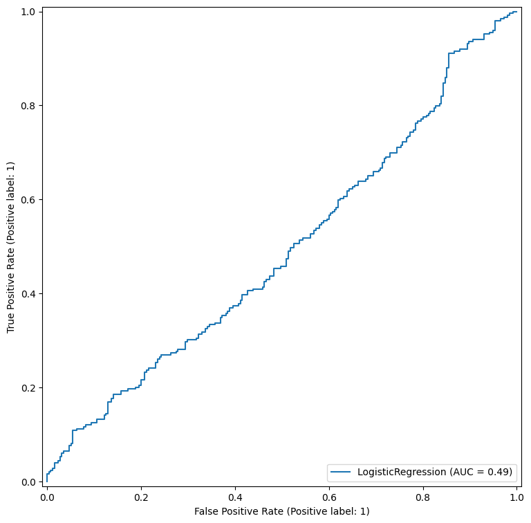

```python
from sklearn.linear_model import LogisticRegression
from sklearn.preprocessing import StandardScaler
from sklearn.metrics import RocCurveDisplay

# use default parameters
lr = LogisticRegression()

# fit to train set
lr.fit(X_train, y_train)

# plot ROC curve, and show AUC for the validation set
RocCurveDisplay.from_estimator(lr, X_val, y_val)
```

Logistic regression doesn't perform well for this problem. An AUC (Area Under the Curve) score of less than 0.5 indicates that the classifier is performing worse than random guessing. Considering the complexity of this task, any AUC score above 0.5 would be considered sufficient.

### Decision Tree

```
<sklearn.metrics._plot.roc_curve.RocCurveDisplay at 0x17c73b370>
```

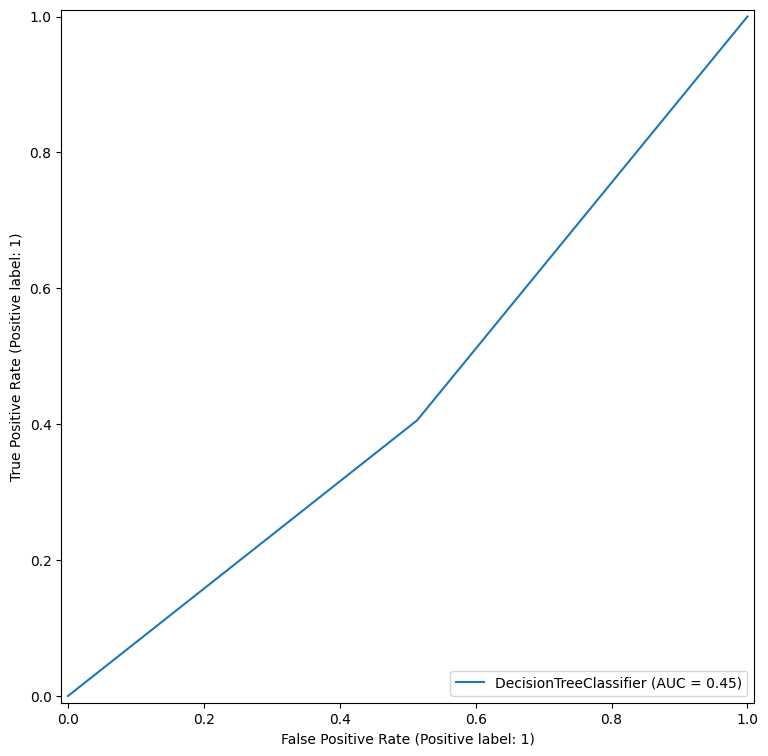

```python
from sklearn.tree import DecisionTreeClassifier

# remember to use the random seed to be able to reproduce the same results
dt = DecisionTreeClassifier(random_state=RANDOM_SEED)
dt.fit(X_train, y_train)

RocCurveDisplay.from_estimator(dt, X_val, y_val)
```

The decision tree underperforms the logistic regression model by 0.04, and its AUC is still below 0.5!

### Random Forest

Now I will try to use many decision trees, i.e., a forest. Random forest is an ensemble model that builds multiple decision trees, each with a different (random) sub-set of attributes.

```
<sklearn.metrics._plot.roc_curve.RocCurveDisplay at 0x17d1b3fa0>
```

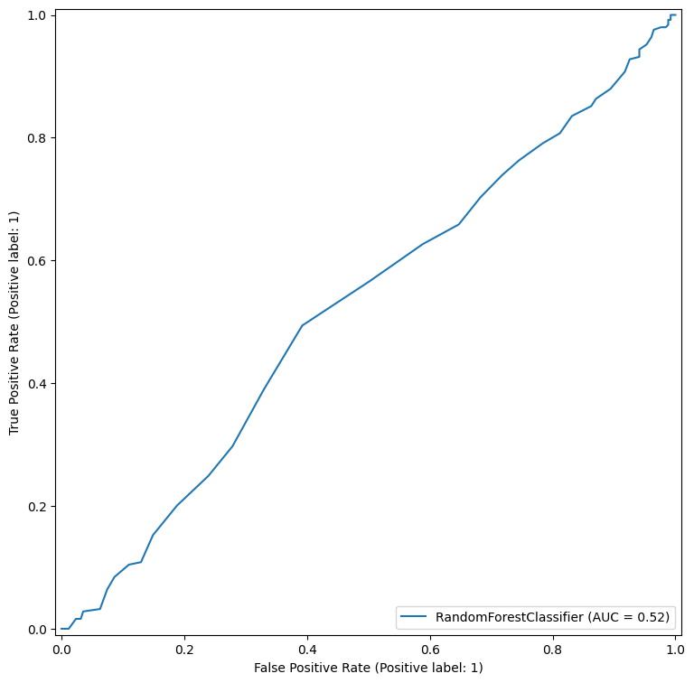

```python
from sklearn.ensemble import RandomForestClassifier

rf = RandomForestClassifier(random_state=RANDOM_SEED)
rf.fit(X_train, y_train)
RocCurveDisplay.from_estimator(rf, X_val, y_val)
```

### Gradient Boosting Ensemble

The final ensemble technique I want to try is gradient boosting. This algorithm sets the stage for the next part, where I will explore a deep learning approach to solve the problem.

```
<sklearn.metrics._plot.roc_curve.RocCurveDisplay at 0x17d483760>
```

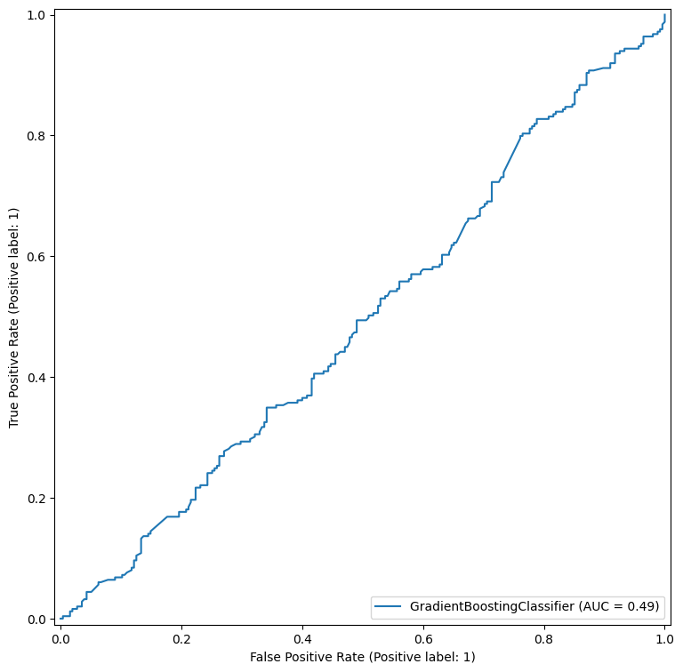

```python
from sklearn.ensemble import GradientBoostingClassifier

gb = GradientBoostingClassifier(random_state=RANDOM_SEED)
gb.fit(X_train, y_train)

RocCurveDisplay.from_estimator(gb, X_val, y_val)
```

Contrary to our expectations, the gradient boosting classifier does not outperform previous models and scored 0.49 AUC. It performs actually the same as Logistic regression

I find out that random forest works best for this data set. In the next section, I will train a deep learning model with the aim to outperform the baseline set here, i.e., AUC = 0.52.

## Deep Learning Algorithm

I am going to use Tensorflow for implementing a small neural network.

```python
pip install tensorflow
```

```python
import tensorflow as tf

# set seed for reproducibility of results
tf.random.set_seed(RANDOM_SEED)

print("Tensorflow version", tf.__version__)
```

```
Tensorflow version 2.16.2
```

I will use Keras to design a small neural network.

```python
model = tf.keras.models.Sequential([
    tf.keras.layers.Input(shape=[X_train.shape[1],]),
    tf.keras.layers.Normalization(axis=-1),
    tf.keras.layers.Dense(10, activation="relu", kernel_initializer='random_normal', bias_initializer='zeros'),
    tf.keras.layers.Dropout(0.2, seed=RANDOM_SEED),
    tf.keras.layers.Dense(5, activation="relu", kernel_initializer='random_normal', bias_initializer='zeros'),
    tf.keras.layers.Dense(1, activation="sigmoid", kernel_initializer='random_normal', bias_initializer='zeros')
])
```

```python
# this configures the model's loss function, weight optimizer, and metrics to keep track of
model.compile(
    loss="binary_crossentropy",
    optimizer=tf.keras.optimizers.Adam(),
    metrics=['AUC']
)
```

I am going to train my model for 50 epochs, and keep track of its loss (binary_crossentropy) and AUC values during each epoch.

To prevent overfitting, I am implementing two callbacks: (1) learning rate scheduler, and (2) early stopping callback.

```python
def learning_rate_scheduler(epoch, learning_rate):
    """Learning rate decay callback."""
    if epoch < 5:
        return learning_rate
    else:
        return float(tf.keras.backend.get_value(learning_rate * tf.math.exp(-0.01)))

early_stopping_callback = tf.keras.callbacks.EarlyStopping(patience=10, verbose=1, restore_best_weights=True)
learning_rate_callback = tf.keras.callbacks.LearningRateScheduler(learning_rate_scheduler)
```

```python
# the model.fit(...) method returns a 'history' object with stats about the training
history = model.fit(
    x=X_train,
    y=y_train,
    validation_data=(X_val, y_val),
    epochs=50,
    verbose=1,
    callbacks=[early_stopping_callback, learning_rate_callback])
```

```
79/79 ━━━━━━━━━━━━━━━━━━━━ 1s 2ms/step - AUC: 0.5121 - loss: 1914.3799 - val_AUC: 0.5000 - val_loss: 0.6933 - learning_rate: 0.0010
79/79 ━━━━━━━━━━━━━━━━━━━━ 0s 806us/step - AUC: 0.4967 - loss: 21.9034 - val_AUC: 0.5000 - val_loss: 0.6933 - learning_rate: 0.0010
79/79 ━━━━━━━━━━━━━━━━━━━━ 0s 800us/step - AUC: 0.5210 - loss: 5.2054 - val_AUC: 0.5000 - val_loss: 0.6933 - learning_rate: 0.0010
79/79 ━━━━━━━━━━━━━━━━━━━━ 0s 791us/step - AUC: 0.5106 - loss: 3.8619 - val_AUC: 0.5000 - val_loss: 0.6932 - learning_rate: 0.0010
79/79 ━━━━━━━━━━━━━━━━━━━━ 0s 892us/step - AUC: 0.4832 - loss: 5.1921 - val_AUC: 0.5000 - val_loss: 0.6932 - learning_rate: 0.0010
79/79 ━━━━━━━━━━━━━━━━━━━━ 0s 846us/step - AUC: 0.4968 - loss: 9.7741 - val_AUC: 0.5000 - val_loss: 0.6932 - learning_rate: 9.9005e-04
79/79 ━━━━━━━━━━━━━━━━━━━━ 0s 864us/step - AUC: 0.4925 - loss: 8.1999 - val_AUC: 0.5000 - val_loss: 0.6931 - learning_rate: 9.8020e-04
79/79 ━━━━━━━━━━━━━━━━━━━━ 0s 821us/step - AUC: 0.5169 - loss: 10.1824 - val_AUC: 0.5000 - val_loss: 0.6932 - learning_rate: 9.7045e-04
79/79 ━━━━━━━━━━━━━━━━━━━━ 0s 793us/step - AUC: 0.5045 - loss: 7.6708 - val_AUC: 0.5000 - val_loss: 0.6932 - learning_rate: 9.6079e-04
79/79 ━━━━━━━━━━━━━━━━━━━━ 0s 848us/step - AUC: 0.5087 - loss: 3.6784 - val_AUC: 0.5000 - val_loss: 0.6932 - learning_rate: 9.5123e-04
79/79 ━━━━━━━━━━━━━━━━━━━━ 0s 815us/step - AUC: 0.4987 - loss: 2.8927 - val_AUC: 0.5000 - val_loss: 0.6931 - learning_rate: 9.4176e-04
79/79 ━━━━━━━━━━━━━━━━━━━━ 0s 814us/step - AUC: 0.4876 - loss: 3.1772 - val_AUC: 0.5000 - val_loss: 0.6931 - learning_rate: 9.3239e-04
79/79 ━━━━━━━━━━━━━━━━━━━━ 0s 846us/step - AUC: 0.4842 - loss: 2.8445 - val_AUC: 0.5000 - val_loss: 0.6931 - learning_rate: 9.2312e-04
79/79 ━━━━━━━━━━━━━━━━━━━━ 0s 823us/step - AUC: 0.5048 - loss: 2.1567 - val_AUC: 0.5000 - val_loss: 0.6931 - learning_rate: 9.1393e-04
79/79 ━━━━━━━━━━━━━━━━━━━━ 0s 798us/step - AUC: 0.5042 - loss: 2.1883 - val_AUC: 0.5000 - val_loss: 0.6931 - learning_rate: 9.0484e-04
79/79 ━━━━━━━━━━━━━━━━━━━━ 0s 795us/step - AUC: 0.5117 - loss: 1.3845 - val_AUC: 0.5000 - val_loss: 0.6931 - learning_rate: 8.9583e-04
79/79 ━━━━━━━━━━━━━━━━━━━━ 0s 865us/step - AUC: 0.5036 - loss: 1.0587 - val_AUC: 0.5000 - val_loss: 0.6931 - learning_rate: 8.8692e-04
79/79 ━━━━━━━━━━━━━━━━━━━━ 0s 891us/step - AUC: 0.4902 - loss: 1.1095 - val_AUC: 0.5000 - val_loss: 0.6931 - learning_rate: 8.7810e-04
79/79 ━━━━━━━━━━━━━━━━━━━━ 0s 853us/step - AUC: 0.5136 - loss: 1.1922 - val_AUC: 0.5000 - val_loss: 0.6931 - learning_rate: 8.6936e-04
79/79 ━━━━━━━━━━━━━━━━━━━━ 0s 865us/step - AUC: 0.4910 - loss: 1.5474 - val_AUC: 0.5000 - val_loss: 0.6931 - learning_rate: 8.6071e-04
79/79 ━━━━━━━━━━━━━━━━━━━━ 0s 824us/step - AUC: 0.4911 - loss: 0.9067 - val_AUC: 0.5000 - val_loss: 0.6931 - learning_rate: 8.5214e-04
79/79 ━━━━━━━━━━━━━━━━━━━━ 0s 806us/step - AUC: 0.4891 - loss: 1.9306 - val_AUC: 0.5000 - val_loss: 0.6931 - learning_rate: 8.4366e-04
79/79 ━━━━━━━━━━━━━━━━━━━━ 0s 814us/step - AUC: 0.5020 - loss: 1.1170 - val_AUC: 0.5000 - val_loss: 0.6931 - learning_rate: 8.3527e-04
79/79 ━━━━━━━━━━━━━━━━━━━━ 0s 802us/step - AUC: 0.5131 - loss: 1.3029 - val_AUC: 0.5000 - val_loss: 0.6931 - learning_rate: 8.2696e-04
79/79 ━━━━━━━━━━━━━━━━━━━━ 0s 822us/step - AUC: 0.4872 - loss: 0.8444 - val_AUC: 0.5000 - val_loss: 0.6931 - learning_rate: 8.1873e-04
79/79 ━━━━━━━━━━━━━━━━━━━━ 0s 854us/step - AUC: 0.4986 - loss: 1.0024 - val_AUC: 0.5000 - val_loss: 0.6931 - learning_rate: 8.1058e-04
79/79 ━━━━━━━━━━━━━━━━━━━━ 0s 845us/step - AUC: 0.5176 - loss: 0.7427 - val_AUC: 0.5000 - val_loss: 0.6931 - learning_rate: 8.0252e-04
79/79 ━━━━━━━━━━━━━━━━━━━━ 0s 810us/step - AUC: 0.4940 - loss: 0.9505 - val_AUC: 0.5000 - val_loss: 0.6931 - learning_rate: 7.9453e-04
79/79 ━━━━━━━━━━━━━━━━━━━━ 0s 803us/step - AUC: 0.4976 - loss: 0.8580 - val_AUC: 0.5000 - val_loss: 0.6931 - learning_rate: 7.8663e-04
79/79 ━━━━━━━━━━━━━━━━━━━━ 0s 848us/step - AUC: 0.4989 - loss: 0.9048 - val_AUC: 0.5000 - val_loss: 0.6931 - learning_rate: 7.7880e-04
79/79 ━━━━━━━━━━━━━━━━━━━━ 0s 794us/step - AUC: 0.4979 - loss: 0.7822 - val_AUC: 0.5000 - val_loss: 0.6931 - learning_rate: 7.7105e-04
79/79 ━━━━━━━━━━━━━━━━━━━━ 0s 823us/step - AUC: 0.4978 - loss: 0.7488 - val_AUC: 0.5000 - val_loss: 0.6931 - learning_rate: 7.6338e-04
79/79 ━━━━━━━━━━━━━━━━━━━━ 0s 810us/step - AUC: 0.4998 - loss: 0.8023 - val_AUC: 0.5000 - val_loss: 0.6931 - learning_rate: 7.5578e-04
79/79 ━━━━━━━━━━━━━━━━━━━━ 0s 786us/step - AUC: 0.5054 - loss: 0.7214 - val_AUC: 0.5000 - val_loss: 0.6931 - learning_rate: 7.4826e-04
79/79 ━━━━━━━━━━━━━━━━━━━━ 0s 845us/step - AUC: 0.4912 - loss: 0.7438 - val_AUC: 0.5000 - val_loss: 0.6931 - learning_rate: 7.4082e-04
Epoch 35: early stopping
Restoring model weights from the end of the best epoch: 25.
```

```python
model.summary()
```

```
Model: "sequential"
```

```
┏━━━━━━━━━━━━━━━━━━━━━━━━━━━━━━━━━┳━━━━━━━━━━━━━━━━━━━━━━━━┳━━━━━━━━━━━━━━━┓
┃ Layer (type)                    ┃ Output Shape           ┃       Param # ┃
┡━━━━━━━━━━━━━━━━━━━━━━━━━━━━━━━━━╇━━━━━━━━━━━━━━━━━━━━━━━━╇━━━━━━━━━━━━━━━┩
│ normalization (Normalization)   │ (None, 10)             │            21 │
├─────────────────────────────────┼────────────────────────┼───────────────┤
│ dense (Dense)                   │ (None, 10)             │           110 │
├─────────────────────────────────┼────────────────────────┼───────────────┤
│ dropout (Dropout)               │ (None, 10)             │             0 │
├─────────────────────────────────┼────────────────────────┼───────────────┤
│ dense_1 (Dense)                 │ (None, 5)              │            55 │
├─────────────────────────────────┼────────────────────────┼───────────────┤
│ dense_2 (Dense)                 │ (None, 1)              │             6 │
└─────────────────────────────────┴────────────────────────┴───────────────┘
```

```
 Total params: 536 (2.10 KB)
```

```
 Trainable params: 171 (684.00 B)
```

```
 Non-trainable params: 21 (88.00 B)
```

```
 Optimizer params: 344 (1.35 KB)
```

Below, I plot the train and validation loss and AUC values as a function of the epoch. I use the matplotlib library, and the history object to do that.

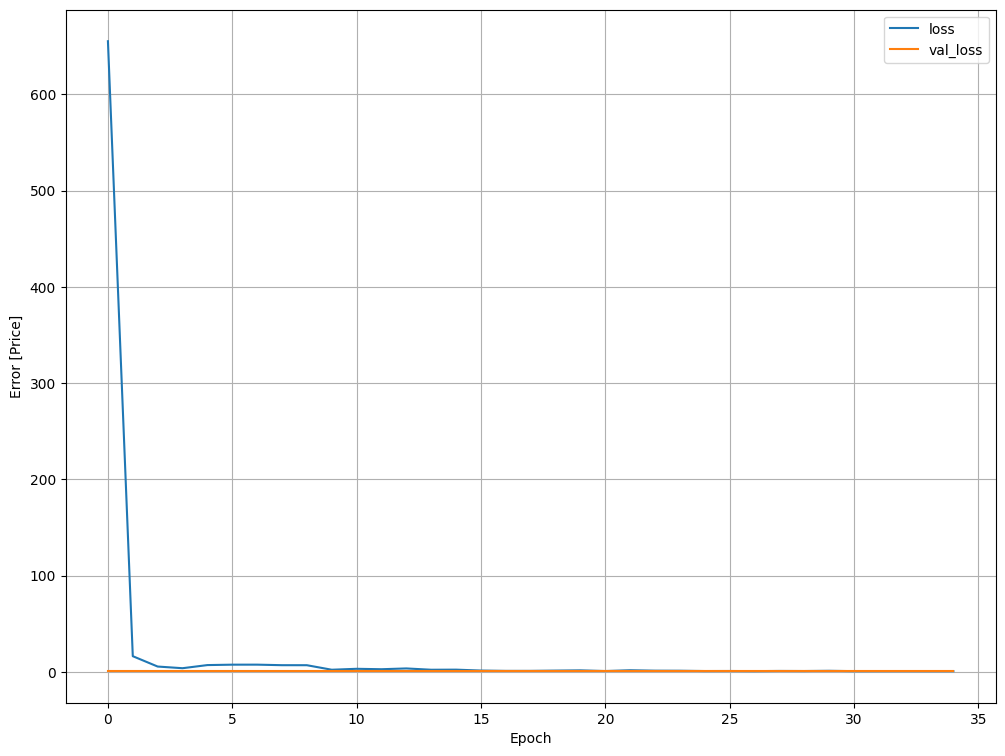

```python
from matplotlib import pyplot as plt

plt.plot(history.history['loss'], label='loss')
plt.plot(history.history['val_loss'], label='val_loss')
plt.xlabel('Epoch')
plt.ylabel('Error [Price]')
plt.legend()
plt.grid(True)
```

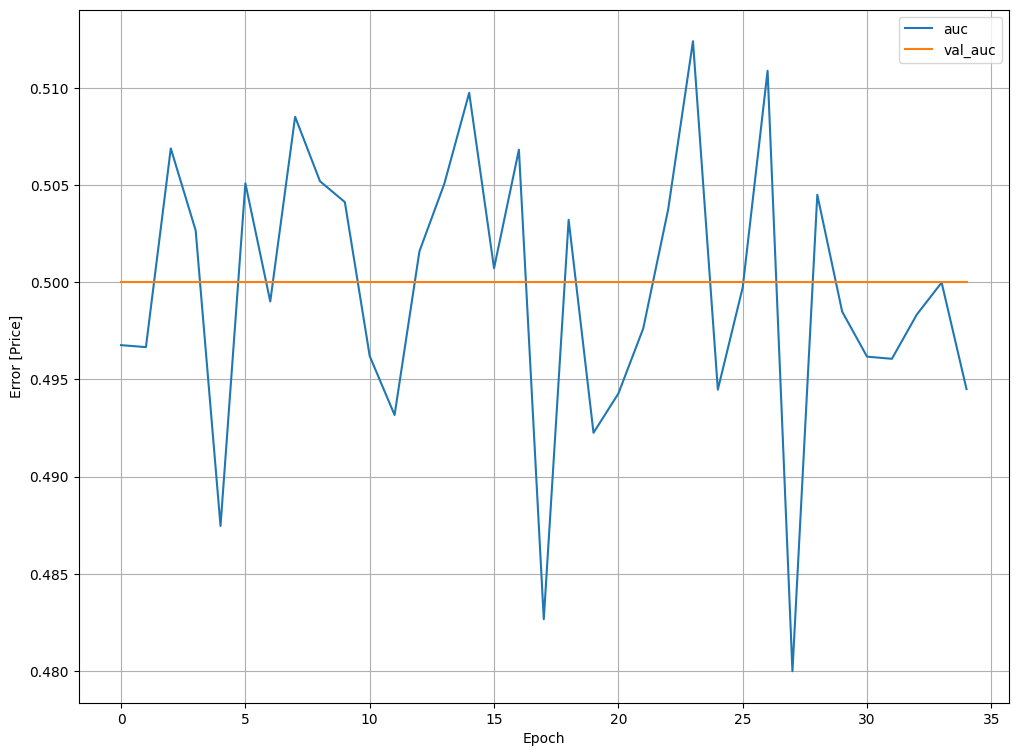

```python
plt.plot(history.history['AUC'], label='auc')
plt.plot(history.history['val_AUC'], label='val_auc')
plt.xlabel('Epoch')
plt.ylabel('Error [Price]')
plt.legend()
plt.grid(True)
```

## Conclusion

The random forest provided the best AUC score on the validation set. It is a common machine learning practice to train multiple models on the same train/validation data set and provide a model that works best. To simulate a production environment, I have held the test set aside until now.

As a bonus, in the last cell, I am showing a feature importance plot, which plots the importance of each feature in regard to the predictive performance of the model (the higher the value the more important the feature is for determining the value of the target variable).

```
<sklearn.metrics._plot.roc_curve.RocCurveDisplay at 0x30fae3a90>
```

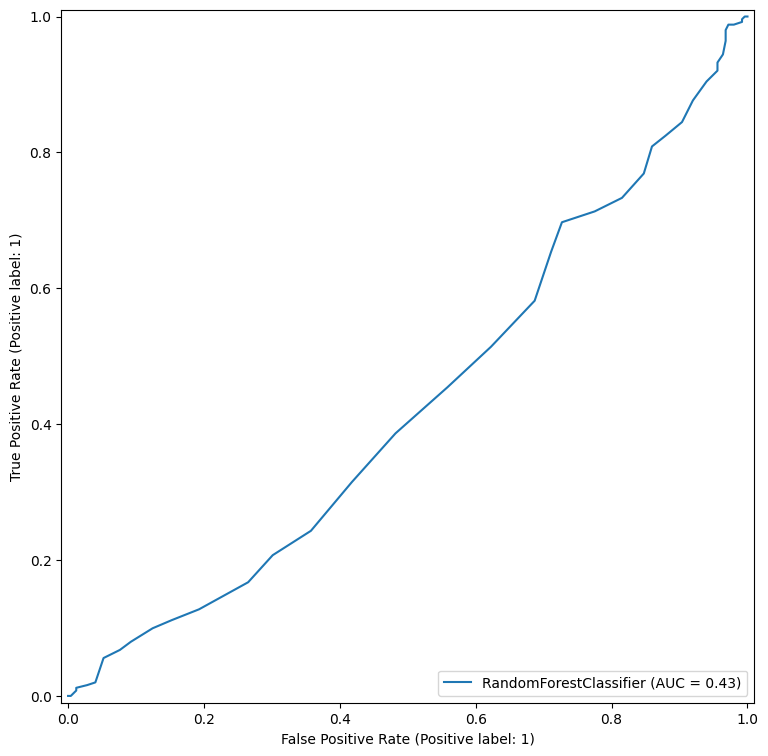

```python
RocCurveDisplay.from_estimator(rf, X_test, y_test)
```

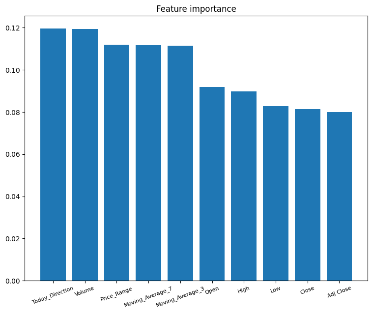

```python
import numpy as np
# Calculate feature importances
importances = rf.feature_importances_
# Sort feature importances in descending order
indices = np.argsort(importances)[::-1]

# Rearrange feature names so they match the sorted feature importances
names = [df_train[X_cols].columns[i] for i in indices]

_ = plt.figure(figsize=(9, 7))
plt.bar(names, importances[indices])
_ = plt.title("Feature importance")
_ = plt.xticks(rotation=20, fontsize = 8)
```